# A3: SPL Library Checkouts

### Summary Information

These will likely be calculated using your DPLYR skills, answering questions such as:

- What is the average number of checkouts for each item?
- What is the month or year with the most/least checkouts for a book that you’re interested in?
- What is the month or year with the most/least checkouts for ebooks?
- How has the number of print book checkouts changed over time?

Feel free to calculate and report values that you find relevant.

### First Trends Over Time Chart

The first chart that you will create and include will show the trend over time of your variable/topic/interest. Think carefully about what you want to communicate to your user (you may have to find relevant trends in the dataset first!). Here are some requirements to help guide your design:

- Show more than one, but fewer than ~10 trends
  - For example, two books, or 5 different mediums
- You must have clear x and y axis labels
- The chart needs a clear title
- You need a legend for your different line colors and a clear - legend title In your .Rmd file, make sure to describe why you included the chart, and what patterns emerged

When we say “clear” or “human readable” titles and labels, that means that you should not just display the variable name.

Here’s an example of how to run an R script inside an RMarkdown file:

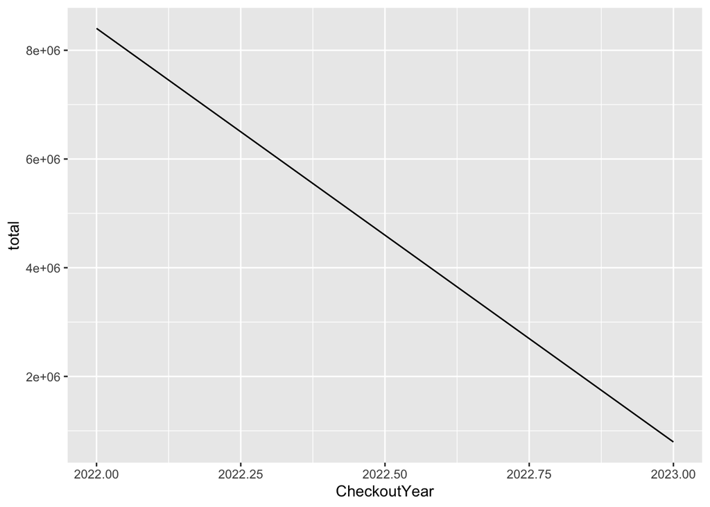

### Second Trends Over Time Chart

The second chart that you will create and include will show another trend over time of your variable/topic/interest. Think carefully about what you want to communicate to your user (you may have to find relevant trends in the dataset first!). Here are some requirements to help guide your design:

- Show more than one, but fewer than ~10 trends
  - For example, two books, or 5 different mediums
- You must have clear x and y axis labels
- The chart needs a clear title
- You need a legend for your different line colors and a clear - legend title In your .Rmd file, make sure to describe why you included the chart, and what patterns emerged

When we say “clear” or “human readable” titles and labels, that means that you should not just display the variable name.

Here’s an example of how to run an R script inside an RMarkdown file:

[figure not shown]

### Your Choice

The last chart is up to you. It could be a line plot, scatter plot, histogram, bar plot, stacked bar plot, and more. Here are some requirements to help guide your design:

- You must have clear x and y axis labels
- The chart needs a clear title
- You need a legend for your different line colors and a clear legend title

Here’s an example of how to run an R script inside an RMarkdown file:

[figure not shown]